# BISC 307, Lab 3: Plant Traits & Physiology

Prof. Jackie Hatala Matthes, FA 2020

Lab: 13 November 2020

### Lab 3 Objectives

1. Learn to explore patterns in data that can be used to generate hypotheses and examine how ecological and evolutionary processes control photosynthesis.
2. Examine variation within variables, and covariation among variables within a global dataset for leaf carbon exchange.
3. Use a non-dimensional statistical model (principal components analysis) to describe patterns among many variables within the data.

### 1. Introduction

In this lab, we’ll work with a [global dataset](http://onlinelibrary.wiley.com/doi/10.1002/ecy.1992/abstract) of leaf carbon exchange measurements and leaf traits collected across 626 individual plants of 98 species at 12 sites in North and South America that span 58 degrees of latitude and are published in [Smith & Dukes (2017)](http://onlinelibrary.wiley.com/doi/10.1002/ecy.1992/abstract). Our lab objectives for today will practice and build on the sections on Exploratory Data Analysis that you read in preparation for this week’s lab, [Sections 7.1-7.6 from the R for Data Science book](http://r4ds.had.co.nz/exploratory-data-analysis.html), in addition to exploring global patterns in leaf carbon/water exchange.

First, we’ll load the tidyverse library.

```r
# Load libraries
library(tidyverse)

# Some that we'll use for stats later on:
#install.packages("Hmisc")
library(Hmisc)
#install.packages("corrplot")
library(corrplot)
# Install factoextra, a package that is good at PCA stuff
#install.packages("factoextra")
library(factoextra)
```

### 2. Global dataset of Vcmax, Jmax, and Rd

This global dataset used A-Ci photosynthesis curves collected from plants within ecosystems in North and South America to find Vcmax, Jmax, and Rd. This lab will focus on examining patterns, generating questions, and testing hypotheses for the values of Vcmax, Jmax, and Rd that are in the `LCE_data.csv` file (LCE = leaf carbon exchange). First, let’s load the data and see what it looks like:

```r
# Read LCE data frame
LCE_global <- read_csv("data/LCE/LCE_data.csv") %>%
  mutate(SLA = LA/LM) # Make specific leaf area column (leaf area/leaf mass)
LCE_global
```

```
## # A tibble: 598 x 132
##    index Date   Year   Day Location   Lat   Lon Genus Species   Rep
##    <dbl> <chr> <dbl> <dbl> <chr>    <dbl> <dbl> <chr> <chr>   <dbl>
##  1     1 5/19…  2015   139 LaSelva   10.4 -84.0 Albi… adinoc…     1
##  2     2 5/21…  2015   141 LaSelva   10.4 -84.0 Alch… costar…     1
##  3     3 5/22…  2015   142 LaSelva   10.4 -84.0 Anno… papili…     1
##  4     4 5/23…  2015   143 LaSelva   10.4 -84.0 Anno… papili…     2
##  5     5 5/23…  2015   143 LaSelva   10.4 -84.0 Anno… papili…     3
##  6     6 5/26…  2015   146 LaSelva   10.4 -84.0 Anno… papili…     4
##  7     7 5/26…  2015   146 LaSelva   10.4 -84.0 Anno… papili…     5
##  8     8 5/26…  2015   146 LaSelva   10.4 -84.0 Anno… papili…     6
##  9     9 5/27…  2015   147 LaSelva   10.4 -84.0 Anno… papili…     7
## 10    10 5/24…  2015   144 LaSelva   10.4 -84.0 Apei… membra…     1
## # … with 588 more rows, and 122 more variables: Phenology <chr>,
## #   Lifespan <chr>, Photosynthesis <chr>, Stature <chr>, Juvenile <chr>,
## #   Vcmax <dbl>, Jmax <dbl>, Vpmax <dbl>, Rd <dbl>, Tleaf_photo <dbl>,
## #   Tleaf_R <dbl>, LA <dbl>, LM <dbl>, CN <dbl>, Nper <dbl>, Cper <dbl>,
## #   LWP_MPa <dbl>, DBH <dbl>, Height <dbl>, SMper <dbl>, FCper <dbl>,
## #   Satper <dbl>, Tavg1 <dbl>, Tavg2 <dbl>, Tavg3 <dbl>, Tavg4 <dbl>,
## #   Tavg5 <dbl>, Tavg6 <dbl>, Tavg7 <dbl>, Tavg8 <dbl>, Tavg9 <dbl>,
## #   Tavg10 <dbl>, Tavg11 <dbl>, Tavg12 <dbl>, Tavg13 <dbl>, Tavg14 <dbl>,
## #   Tavg15 <dbl>, Tavg16 <dbl>, Tavg17 <dbl>, Tavg18 <dbl>, Tavg19 <dbl>,
## #   Tavg20 <dbl>, Tavg21 <dbl>, Tavg22 <dbl>, Tavg23 <dbl>, Tavg24 <dbl>,
## #   Tavg25 <dbl>, Tavg26 <dbl>, Tavg27 <dbl>, Tavg28 <dbl>, Tavg29 <dbl>,
## #   Tavg30 <dbl>, Tavg31 <dbl>, Tavg32 <dbl>, Tavg33 <dbl>, Tavg34 <dbl>,
## #   Tavg35 <dbl>, Tavg36 <dbl>, Tavg37 <dbl>, Tavg38 <dbl>, Tavg39 <dbl>,
## #   Tavg40 <dbl>, Tavg41 <dbl>, Tavg42 <dbl>, Tavg43 <dbl>, Tavg44 <dbl>,
## #   Tavg45 <dbl>, Tavg46 <dbl>, Tavg47 <dbl>, Tavg48 <dbl>, Tavg49 <dbl>,
## #   Tavg50 <dbl>, Tavg51 <dbl>, Tavg52 <dbl>, Tavg53 <dbl>, Tavg54 <dbl>,
## #   Tavg55 <dbl>, Tavg56 <dbl>, Tavg57 <dbl>, Tavg58 <dbl>, Tavg59 <dbl>,
## #   Tavg60 <dbl>, Tavg61 <dbl>, Tavg62 <dbl>, Tavg63 <dbl>, Tavg64 <dbl>,
## #   Tavg65 <dbl>, Tavg66 <dbl>, Tavg67 <dbl>, Tavg68 <dbl>, Tavg69 <dbl>,
## #   Tavg70 <dbl>, Tavg71 <dbl>, Tavg72 <dbl>, Tavg73 <dbl>, Tavg74 <dbl>,
## #   Tavg75 <dbl>, Tavg76 <dbl>, Tavg77 <dbl>, Tavg78 <dbl>, …
```

One of the first things to do when you start exploring a big dataset like this that you haven’t seen before is to understand the dimensions of the data (which we can see from looking at the data frame above), and what type of replication there is within the major cateogires of the dataset. This can help to inform what to do next with the data.

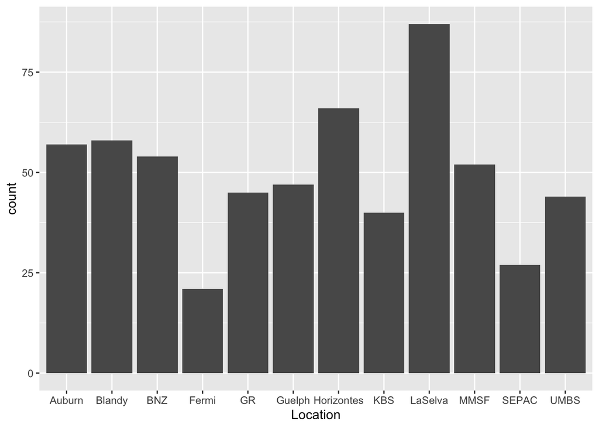

```r
# Plot data by Location
ggplot(data = LCE_global) +
  geom_bar(mapping = aes(x = Location))
```

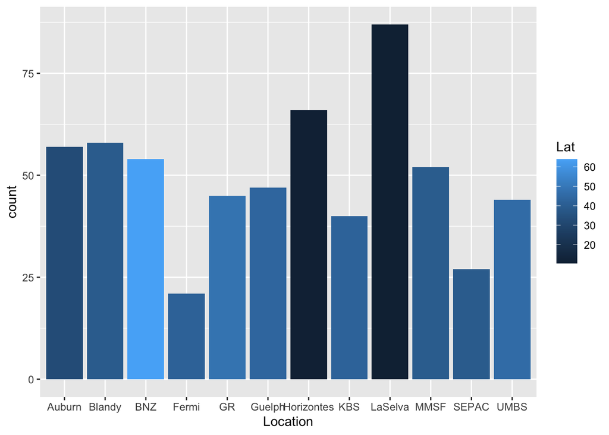

```r
# Plot data by Location - add color to see which latitude sites are at
ggplot(data = LCE_global) +
  geom_bar(mapping = aes(x = Location, fill = Lat))
```

**Code Challenge 1: Examine numbers of replicates within at least two additional variables that you might be interested in examining further. Remember that the potential variables for exploration are all the column names of the LCE_global data frame.**

### 3. Visualizing variation within a single variable & covariation among a categorical and continuous variable

1. Could this pattern be due to coincidence (i.e. random chance)?
2. How can you describe the relationship implied by the pattern?
3. How strong is the relationship implied by the pattern?
4. What other variables might affect the relationship?
5. Does the relationship change if you look at individual subgroups of the data?

Visualizing your data is one of the most powerful ways to look for patterns and to also convince others that these patterns exist. It’s always helpful to start with visualization and exploratory data analysis to examine patterns in your data that address your research question.

We can also look at the probability distribution of our continuous variables with geom_freqpoly:

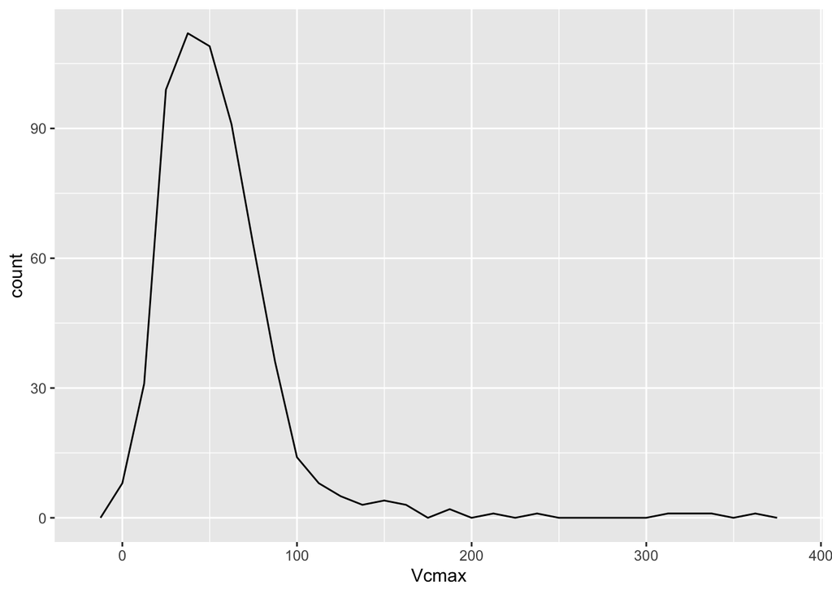

```r
# Plot Vcmax distribution
ggplot(data = LCE_global) +
  geom_freqpoly(aes(x = Vcmax))
```

We can also use visual techniques to examine the covariation between a continuous and categorical variable. Let’s start by examining the distribution for Vcmax within C3 and C4 plants:

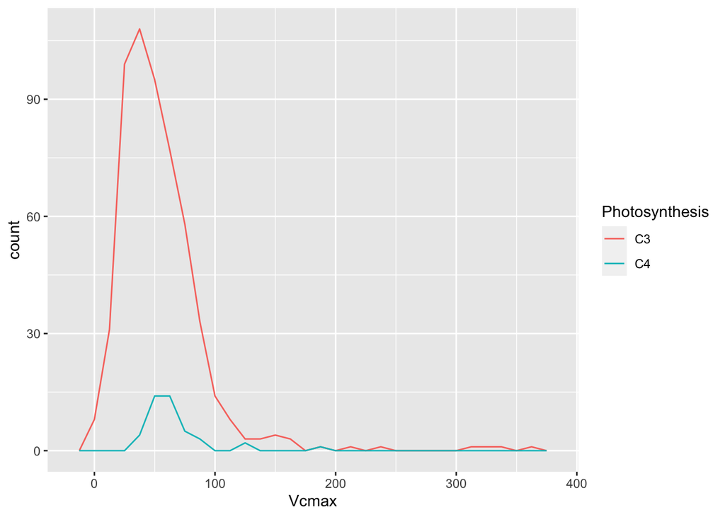

```r
# Plot distributions of Vcmax, colored by C3/C4 Photosynthesis
ggplot(data = LCE_global) +
  geom_freqpoly(mapping = aes(x = Vcmax, color = Photosynthesis))
```

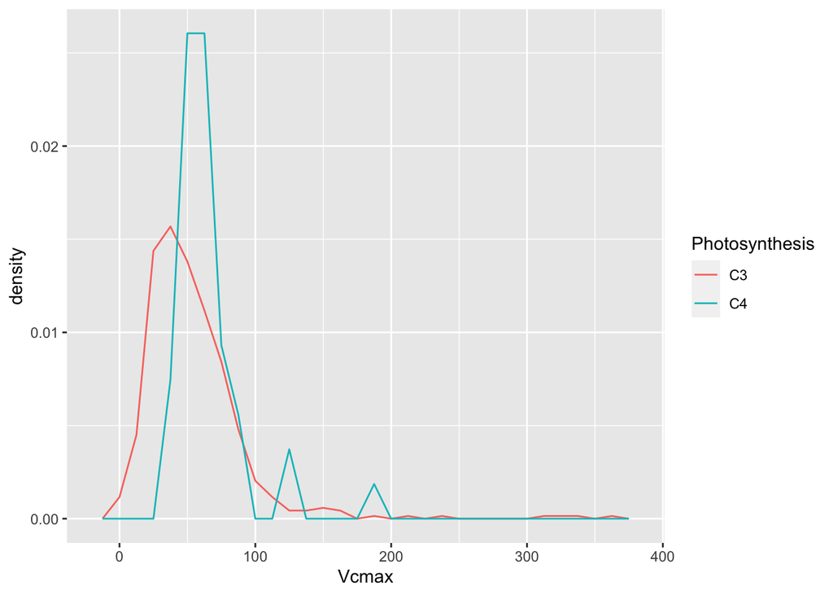

```r
# Alternate Plot: scaled by probability density (integrates to 1.0, rather than showing counts)
ggplot(data = LCE_global) +
  geom_freqpoly(mapping = aes(x = Vcmax, y = ..density.., color = Photosynthesis))
```

Visualizing the data distributions will help to understand the range of values, show differences among categories, and highlight interesting aspects of your data (groups, outliers, etc.). This can also inform details of statistical tests that you might use to quantify differences among groups in your data.

From this we see that the distributions for Vcmax are not normal, but instead they have many low values and then a long tail in the positive direction with higher values as well. This is the case for most of the continuous variables in these data, which make them very good candidates for a log-transformation before further analysis. Taking the natural logarithm of these variables will make them more normally distrubted. Take my word for it that I checked the distributions of the following variables and they all fit the distirbution where a log-transformation would make them more normally distributed (i.e., more like a bell curve).

```r
# Log-transform the continuous variables with long tails
LCE_global <- LCE_global %>%
  mutate(Vcmax_log = log(Vcmax), Jmax_log = log(Jmax),
         Rd_log = log(Rd), SLA_log = log(SLA),
         Nper_log = log(Nper), CN_log = log(CN))
```

### 4. Visualizing covariation among variables

There are several continuous variables for which we can examine the connection to the leaf carbon exchange variables within this dataset. Let’s first look to see whether specific leaf area (leaf area per g biomass) is correlated to Vcmax:

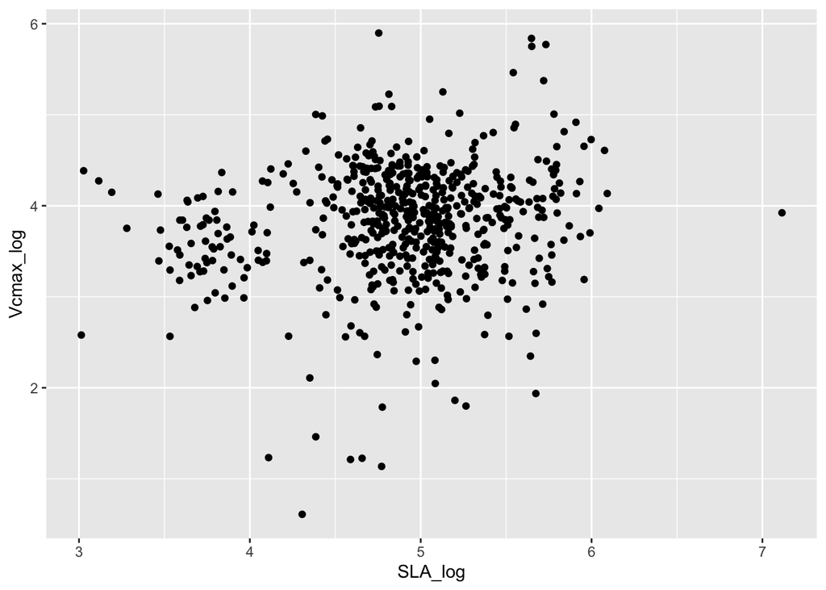

```r
# Plot leaf mass (LM) against Vcmax
ggplot(data = LCE_global) +
  geom_point(mapping = aes(x = SLA_log, y = Vcmax_log))
```

We can also make a large plot that shows all of the pairwise correlations between variables in our dataset. For this, we’ll first need to select only continuous variables from our data frame and drop observations that are NA. Then, we will calculate the correlation matrix. Finally, we can use the `corrplot()` function from the `corrplot` package to visualize the correlation matrix (correlogram).

```r
# 1. Select continuous variables from data frame
# 2. Drop rows with NA values from the dataset
LCE_cont <- select(LCE_global, Vcmax_log, Jmax_log, Rd_log, SLA_log,
                   CN_log, Nper_log, Cper) %>%
  drop_na()

# 3. Calculate the correlation matrix, including p-values for each comparison
LCE_cor <- rcorr(as.matrix(LCE_cont), type="pearson")
LCE_cor$r # look at correlation coefficients (r)
```

```
##            Vcmax_log   Jmax_log        Rd_log     SLA_log     CN_log
## Vcmax_log  1.0000000  0.8102739  3.563324e-01  0.14854578 -0.3558209
## Jmax_log   0.8102739  1.0000000  3.678420e-01  0.15421711 -0.3191273
## Rd_log     0.3563324  0.3678420  1.000000e+00  0.09826362 -0.3829315
## SLA_log    0.1485458  0.1542171  9.826362e-02  1.00000000 -0.7064644
## CN_log    -0.3558209 -0.3191273 -3.829315e-01 -0.70646443  1.0000000
## Nper_log   0.3398430  0.2886156  3.923412e-01  0.66167795 -0.9826936
## Cper      -0.1261916 -0.2092146 -6.004036e-05 -0.31874859  0.2172432
##              Nper_log          Cper
## Vcmax_log  0.33984302 -1.261916e-01
## Jmax_log   0.28861557 -2.092146e-01
## Rd_log     0.39234123 -6.004036e-05
## SLA_log    0.66167795 -3.187486e-01
## CN_log    -0.98269360  2.172432e-01
## Nper_log   1.00000000 -3.618361e-02
## Cper      -0.03618361  1.000000e+00
```

```r
LCE_cor$P # look at p-values for each pairwise comparison
```

```
##              Vcmax_log     Jmax_log     Rd_log      SLA_log       CN_log
## Vcmax_log           NA 0.000000e+00 0.00000000 3.045925e-04 0.000000e+00
## Jmax_log  0.0000000000           NA 0.00000000 1.762135e-04 2.220446e-15
## Rd_log    0.0000000000 0.000000e+00         NA 1.724557e-02 0.000000e+00
## SLA_log   0.0003045925 1.762135e-04 0.01724557           NA 0.000000e+00
## CN_log    0.0000000000 2.220446e-15 0.00000000 0.000000e+00           NA
## Nper_log  0.0000000000 1.003864e-12 0.00000000 0.000000e+00 0.000000e+00
## Cper      0.0021904372 3.141185e-07 0.99884182 2.664535e-15 1.062015e-07
##               Nper_log         Cper
## Vcmax_log 0.000000e+00 2.190437e-03
## Jmax_log  1.003864e-12 3.141185e-07
## Rd_log    0.000000e+00 9.988418e-01
## SLA_log   0.000000e+00 2.664535e-15
## CN_log    0.000000e+00 1.062015e-07
## Nper_log            NA 3.815317e-01
## Cper      3.815317e-01           NA
```

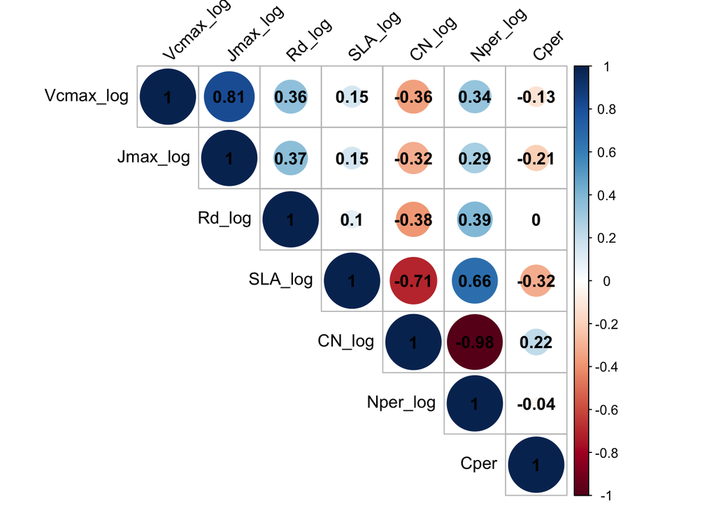

```r
# 4. Make plot with correlation matrix (called a correlogram)
corrplot(LCE_cor$r, type = "upper",
         tl.col = "black",
         tl.srt = 45, # tilt top row to 45-degree angle
         addCoef.col = "black")
```

We can also make a correlogram that uses the p-values of the pairwise correlation tests that indicates the comparisons that were significant. The code below will leave pairwise cells blank if they are not correlated at the sig.level specified:

[figure not shown]

```r
# Correlogram with p-value indicators
corrplot(LCE_cor$r, type = "upper",
         tl.col = "black",
         tl.srt = 45, # tilt top row to 45-degree angle
         p.mat = LCE_cor$P, # p-values from matrix
         sig.level = 0.05, # alpha value for signficance
         addCoef.col = "black",
         insig = "blank")
```

**Code Challenge 2: In your group, discuss the results from this correlation matrix. Do they align with your expectations given you knowledge about photosynthesis and leaf traits? Why or why not?**